# A3: Incarceration

### Introduction

I choose the dataset [Smaller dataset about prison/jail population per 100,000 people (rate) per county/state starting at 1990 in Washington] (https://github.com/melaniewalsh/Neat-Datasets/raw/main/us-prison-jail-rates-1990-WA.csv) This dataset provides detailed insights into prison and jail rates in Washington State from 1990 to 2018. This dataset is instrumental for analyzing trends over nearly three decades, focusing on the rates of incarceration per 100,000 people. Rates is formatted such that each unit represents 1 individual per 100,000 in the population, making the data both accessible and interpretable in terms of understanding the scale of incarceration relative to the total population size. In this report, I analyzed key variables reflecting incarceration rates across Washington State, with a specific focus on racial disparities. The variables examined include the Total Jail Population Rate, average black jail population rate, and other specific rates for Black and White populations, and some other relevant variables which help trace trends and evaluate the effectiveness of interventions.

### Summary Information

The summary of jail population rates across Washington State underscores significant insights into racial disparities and the dynamics of incarceration. In the most recent year of data, 39 counties reported, offering a comprehensive overview for analysis. The maximum total jail population rate is about 992.82, and the highest black jail population rate is about 31000 in Pend Oreille County. The data reveals stark disparities, the maximum jail population rate for Black individuals is significantly higher than for White individuals, with the largest difference recorded in about 4052.54. Furthermore, the recent average jail population rates show that Black individuals are incarcerated at a higher rate compared to their White counterparts.The average white jail population rate is about 326.48, and the average black jail population rate is about 1052.11. The change in the average Black jail population rate over the years, which is about -707.576.These findings underscore the need for continued efforts to address racial inequalities within the criminal justice system of Washington State, providing a crucial basis for policymakers and community activists focused on reform and equity.

```r
library(dplyr)
prison_wa <- read.csv("https://github.com/melaniewalsh/Neat-Datasets/raw/main/us-prison-jail-rates-1990-WA.csv")

summary_info <- list()
## Total number of counties in Washington in this dataset
summary_info$num_county <- prison_wa %>%
  filter(year == max(year)) %>%
  summarize(num = n()) %>%
  pull(num)
## The maximum total jail population rate in this dataset
summary_info$max_jail_rate <- prison_wa %>%
  filter(total_jail_pop_rate == max(total_jail_pop_rate, na.rm = TRUE)) %>%
  pull(total_jail_pop_rate)
## The maximum black jail population rate in this dataset
summary_info$max_jail_rate_black <- prison_wa %>%
  filter(black_jail_pop_rate == max(black_jail_pop_rate, na.rm = TRUE)) %>%
  pull(black_jail_pop_rate)
## The county of maximum black jail population rate in this dataset
summary_info$max_jail_rate_black_county <- prison_wa %>%
  filter(black_jail_pop_rate == max(black_jail_pop_rate, na.rm = TRUE)) %>%
  pull(county_name)
## The difference between maximum black jail population rate and maximum white
## jail population rate
summary_info$diff_max_race_jail_rate <- prison_wa %>%
  filter(year == max(year)) %>%
  summarize(max_diff = max(black_jail_pop_rate, na.rm = TRUE) -
              max(white_jail_pop_rate, na.rm = TRUE)) %>%
  pull(max_diff)
## The average white jail population rate in the recent year in this dataset
summary_info$recent_avg_jail_rate_white <- prison_wa %>%
  filter(year == max(year)) %>%
  summarize(avg_rate = mean(white_jail_pop_rate, na.rm = TRUE)) %>%
  pull(avg_rate)
## The average black jail population rate in the recent year in this dataset
summary_info$recent_avg_jail_rate_black <- prison_wa %>%
  filter(year == max(year)) %>%
  summarize(avg_rate = mean(black_jail_pop_rate, na.rm = TRUE)) %>%
  pull(avg_rate)
## The change of average black jail population rate over years
summary_info$change_avg_black_jail_rate <- prison_wa %>%
  group_by(year) %>%
  summarize(avg_rate = mean(black_jail_pop_rate, na.rm = TRUE)) %>%
  filter(year == max(year) | year == min(year)) %>%
  summarize(change = diff(avg_rate)) %>%
  pull(change)

summary_info
```

```
## $num_county
## [1] 39
##
## $max_jail_rate
## [1] 992.82
##
## $max_jail_rate_black
## [1] 31000
##
## $max_jail_rate_black_county
## [1] "Pend Oreille County"
##
## $diff_max_race_jail_rate
## [1] 4052.54
##
## $recent_avg_jail_rate_white
## [1] 326.4833
##
## $recent_avg_jail_rate_black
## [1] 1052.113
##
## $change_avg_black_jail_rate
## [1] -707.576
```

### The Dataset

Who collected the data?

- The data was collected by the Vera Institute of Justice, a nonprofit organization that focuses on criminal justice reform. It was compiled by Census of Jails, Census of State and Federal Adult CorrectionalFacilities, FBI Uniform Crime Reporting Program, National Corrections Reporting Program, Deaths in Custody Reporting Program, Annual Survey of Jails, Centers on Disease Control, U.S. Department of Agriculture, and U.S. Census Bureau. Many organizations combined and cooperated together.

How was the data collected or generated?

- The data was generated using several sources, and it was created through the collaborative efforts of multiple organizations, which enriched it by integrating additional data and information to fill any existing gaps.

Why was the data collected?

- The data was collected to support the Vera Institute of Justice’s project, “In Our Backyards.” This project aims to highlight and address the local impacts of jail and prison use and to understand how incarceration rates vary significantly across different counties and jurisdictions. It seeks to provide a more detailed analysis than state-level data, which can obscure local variations and issues.

How many observations (rows) are in your data?

- There is 1131 rows in this data.

How many features (columns) are in the data?

- There are 23 columns in this data.

What, if any, ethical questions or questions of power do you need to consider when working with this data?

- When analyzing data on incarceration rates, particularly those that distinguish rates by race and demographics, several ethical considerations and power dynamics come into play. Privacy and anonymity are crucial, requiring rigorous measures to prevent the identification of individuals from the data. There’s also a significant risk of reinforcing negative stereotypes and biases if the data is not handled and interpreted with sensitivity towards the groups it represents. The accuracy of the data must be critically assessed to ensure it does not reflect or amplify existing systemic biases in law enforcement or data collection practices. Researchers and policymakers must navigate these ethical waters with transparency about the data’s limitations

What are possible limitations or problems with this data? (at least 200 words)

- Changes in data collection methods over time or reforms in the justice system can affect the consistency of data year over year. For instance, the introduction of new reporting requirements or changes in the legal definitions of crimes can result in apparent trends that are actually artifacts of these changes rather than true changes in behavior or enforcement. The data may not perfectly represent the entire population of interest. For example, smaller jurisdictions or those with less robust data collection infrastructure might be underrepresented. This could skew understandings of regional differences in incarceration practices. There is a significant amount of missing data and timeframe limitations in the dataset (jail data from 1983 to 2016), which can pose a challenge to conducting a thorough and accurate analysis. Since the prison data only covers up to 2016, and the dataset contains information up to 2018, this could lead to a lack of data support when analyzing trends in recent years. This discontinuity may make it difficult for researchers to assess trends in recent years, such as determining whether there is a downward or upward trend in prison population numbers. Large amounts of missing data may bias the results of statistical analyses. For example, if data for a particular county are missing frequently over a period of years, estimates of the average level or growth trend of the prison population in that county may not be accurate. Missing data may affect the representativeness of the results of the analysis, which may also lead to misinterpretation of particular groups or regions.

### Trends Over Time Chart

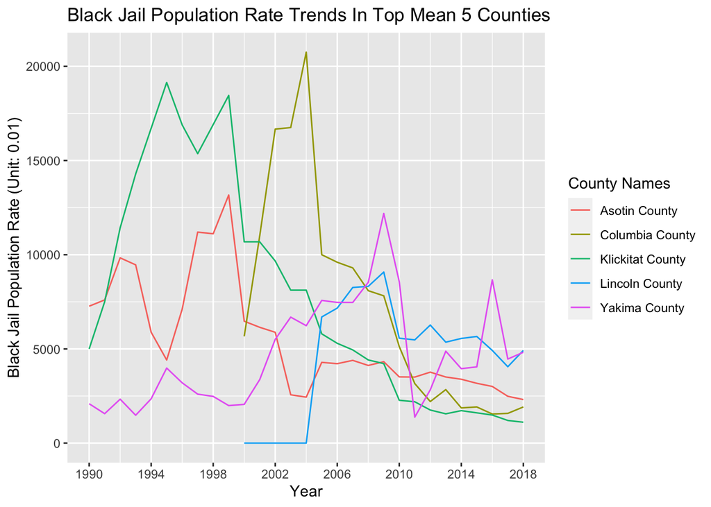

```r
library(ggplot2)

top_5_county <- prison_wa %>%
  filter(!is.na(black_jail_pop_rate)) %>%
  group_by(county_name) %>%
  summarize(mean_rate = mean(black_jail_pop_rate))%>%
  top_n(5, wt = mean_rate) %>%
  pull(county_name)

data1 <- prison_wa %>%
  group_by(year) %>%
  filter(county_name %in% top_5_county) %>%
  filter(!is.na(black_jail_pop_rate))

ggplot(data = data1, aes(x=year, y=black_jail_pop_rate, group=county_name,
                         color=county_name)) +
  geom_line() +
  labs(title = "Black Jail Population Rate Trends In Top Mean 5 Counties",
       x = "Year", y = "Black Jail Population Rate (Unit: 0.01)",
       color = "County Names") +
  scale_x_continuous(breaks = seq(1990, 2018, by=4))
```

### Variable Comparison Chart

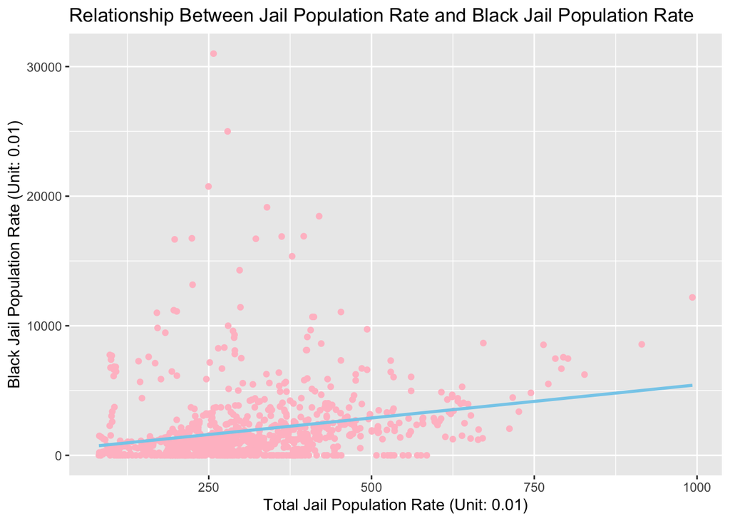

```r
data2 <- prison_wa %>%
  filter(!is.na(total_jail_pop_rate)) %>%
  filter(!is.na(black_jail_pop_rate))

ggplot(data = data2, aes(x=total_jail_pop_rate, y=black_jail_pop_rate)) +
  geom_point(color="pink") +
  geom_smooth(method=lm, color="skyblue", se=FALSE) +
  labs(title = paste("Relationship Between Jail Population Rate and Black",
         "Jail Population Rate"),
       x = "Total Jail Population Rate (Unit: 0.01)",
       y = "Black Jail Population Rate (Unit: 0.01)")
```

### Map

The chart is an essential tool for visualizing and understanding the distribution of incarceration rates among the White population across different counties within Washington State. This map was included to provide a geographic perspective on the disparities or uniformities in prison population rates, Maps provide a clear visual way to spot regional trends and disparities which can be crucial for policy development. Focusing on the White prison population allows for the examination of how incarceration rates differ within this specific demographic. The map shows varying levels of incarceration rates across the state, with some counties exhibiting significantly higher rates than others. Counties with darker shades indicate higher average White prison population rates, suggesting regions where incarceration is more prevalent within this demographic. Conversely, lighter shades indicate lower rates. There are about 3 southwestern counties have relatively dark green, indicating higher white prison population rate. Others are relatively even in white prison population rate.

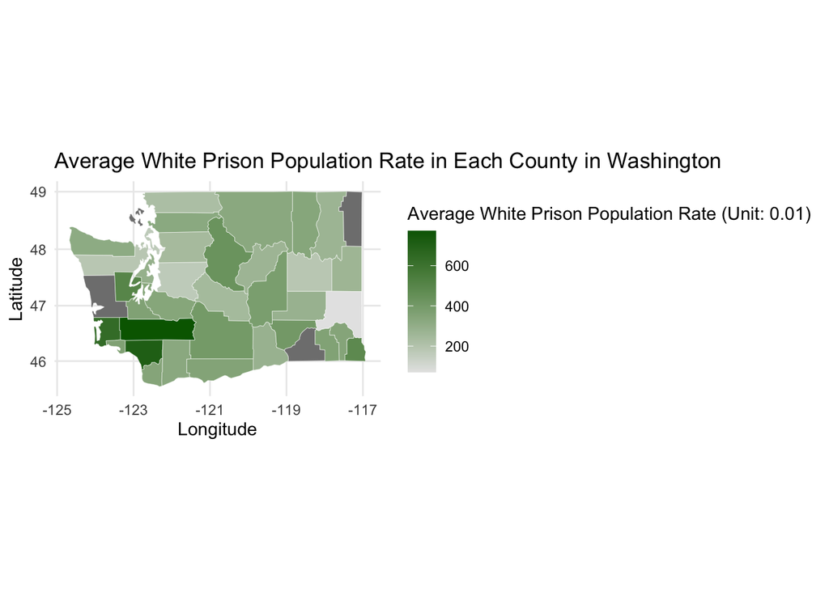

```r
library(mapproj)
library(maps)

map_wa <- prison_wa %>%
  filter(year < 2017) %>%
  mutate(county = tolower(gsub("\\s.*", "", county_name))) %>%
  filter(!is.na(white_prison_pop_rate)) %>%
  group_by(county) %>%
  summarize(avg_white_rate = mean(white_prison_pop_rate)) %>%
  select(county, avg_white_rate)

county_shape <- map_data("county") %>%
  filter(region == "washington") %>%
  rename(county = subregion) %>%
  left_join(map_wa, by = "county")


ggplot(county_shape) +
  geom_polygon(
    mapping = aes(x=long, y=lat, group = group,
                  fill = avg_white_rate),
    color = "white",
    size = .1
  ) +
  coord_map() +
  scale_fill_continuous(low = "grey90", high = "darkgreen") +
  labs(title = paste("Average White Prison Population Rate in Each County",
                     "in Washington"),
       fill = "Average White Prison Population Rate (Unit: 0.01)",
       x = "Longitude",
       y = "Latitude") +
  theme_minimal()
```